# [Extracting Sydney transport data from Twitter](https://www.r-bloggers.com/extracting-sydney-transport-data-from-twitter/)

HAEYOON

2019 9 13

# Introduction

The [@sydstats](https://twitter.com/sydstats) Twitter account uses the [Transport for NSW Open Data API](https://opendata.transport.nsw.gov.au/) to generate daily information about delays on the Sydney train network.

Summaries are posted to Twitter in a text format which is sufficiently consistent to be easily parsed for analysis and visualisation.

# Getting the data

Using the `rtweet` package:

```
## # A tibble: 6 x 90
##   user_id status_id created_at          screen_name text  source
##   <chr>   <chr>     <dttm>              <chr>       <chr> <chr>
## 1 106949~ 11742413~ 2019-09-18 08:38:38 SydStats    The ~ Twitt~
## 2 106949~ 11742412~ 2019-09-18 08:38:33 SydStats    Betw~ Twitt~
## 3 106949~ 11740977~ 2019-09-17 23:08:01 SydStats    The ~ Twitt~
## 4 106949~ 11740976~ 2019-09-17 23:07:56 SydStats    Betw~ Twitt~
## 5 106949~ 11738788~ 2019-09-17 08:38:32 SydStats    The ~ Twitt~
## 6 106949~ 11738788~ 2019-09-17 08:38:26 SydStats    Betw~ Twitt~
## # ... with 84 more variables: display_text_width <dbl>,
## #   reply_to_status_id <chr>, reply_to_user_id <chr>,
## #   reply_to_screen_name <chr>, is_quote <lgl>, is_retweet <lgl>,
## #   favorite_count <int>, retweet_count <int>, quote_count <int>,
## #   reply_count <int>, hashtags <list>, symbols <list>, urls_url <list>,
## #   urls_t.co <list>, urls_expanded_url <list>, media_url <list>,
## #   media_t.co <list>, media_expanded_url <list>, media_type <list>,
## #   ext_media_url <list>, ext_media_t.co <list>,
## #   ext_media_expanded_url <list>, ext_media_type <chr>,
## #   mentions_user_id <list>, mentions_screen_name <list>, lang <chr>,
## #   quoted_status_id <chr>, quoted_text <chr>, quoted_created_at <dttm>,
## #   quoted_source <chr>, quoted_favorite_count <int>,
## #   quoted_retweet_count <int>, quoted_user_id <chr>,
## #   quoted_screen_name <chr>, quoted_name <chr>,
## #   quoted_followers_count <int>, quoted_friends_count <int>,
## #   quoted_statuses_count <int>, quoted_location <chr>,
## #   quoted_description <chr>, quoted_verified <lgl>,
## #   retweet_status_id <chr>, retweet_text <chr>,
## #   retweet_created_at <dttm>, retweet_source <chr>,
## #   retweet_favorite_count <int>, retweet_retweet_count <int>,
## #   retweet_user_id <chr>, retweet_screen_name <chr>, retweet_name <chr>,
## #   retweet_followers_count <int>, retweet_friends_count <int>,
## #   retweet_statuses_count <int>, retweet_location <chr>,
## #   retweet_description <chr>, retweet_verified <lgl>, place_url <chr>,
## #   place_name <chr>, place_full_name <chr>, place_type <chr>,
## #   country <chr>, country_code <chr>, geo_coords <list>,
## #   coords_coords <list>, bbox_coords <list>, status_url <chr>,
## #   name <chr>, location <chr>, description <chr>, url <chr>,
## #   protected <lgl>, followers_count <int>, friends_count <int>,
## #   listed_count <int>, statuses_count <int>, favourites_count <int>,
## #   account_created_at <dttm>, verified <lgl>, profile_url <chr>,
## #   profile_expanded_url <chr>, account_lang <lgl>,
## #   profile_banner_url <chr>, profile_background_url <lgl>,
## #   profile_image_url <chr>
```

The Twitter data can be processed into two datasets. The first dataset contains the year, month, week, day of week, percent of journeys delayed and whether the journeys were during the morning (07:00-09:00) or afternoon (16:00-18:30) peak times.

First 6 rows:

R정규 표현식 #^: 문자열 시작 위치를 매칭 #\s : 간격, #+: 적어도 1 번 매칭한다.(+ 앞에 있는게) #?:많아야 한번 매칭된다.(? 앞에 있는게) #.*:임의 문자를 임의 갯수만큼 매칭한다 #[:digit:] 혹은 \d : 숫자, 0,1,2,3,4,5,6,7,8,9, 동등한 표현 [0-9]

```
## # A tibble: 6 x 8
##   dtstart             dtend               ystart mstart wstart dstart
##   <dttm>              <dttm>               <dbl>  <dbl>  <dbl> <ord>
## 1 2019-09-18 16:00:00 2019-09-18 18:30:00   2019      9     38 수
## 2 2019-09-18 07:00:00 2019-09-18 09:00:00   2019      9     38 수
## 3 2019-09-17 16:00:00 2019-09-17 18:30:00   2019      9     38 화
## 4 2019-09-17 07:00:00 2019-09-17 09:00:00   2019      9     38 화
## 5 2019-09-16 16:00:00 2019-09-16 18:30:00   2019      9     38 월
## 6 2019-09-16 07:00:00 2019-09-16 09:00:00   2019      9     38 월
## # ... with 2 more variables: delayed <dbl>, peak <fct>
```

The second dataset contains the date, longest delay time, service time and service name.

First 6 rows:

```
## # A tibble: 6 x 5
##   created_at          Date       Delay dtime service
##   <dttm>              <date>     <dbl> <chr> <chr>
## 1 2019-09-18 18:38:38 2019-09-18    19 15:46 Liverpool to City Circle via ~
## 2 2019-09-18 09:08:01 2019-09-18    34 08:03 Bondi Junction to Waterfall
## 3 2019-09-17 18:38:32 2019-09-17    15 17:38 Bondi Junction to Waterfall
## 4 2019-09-17 09:08:07 2019-09-17    30 07:16 Campbelltown to Goulburn
## 5 2019-09-16 18:38:37 2019-09-16    20 15:18 Central to Lithgow and Bathur~
## 6 2019-09-16 09:07:48 2019-09-16    32 07:03 Newcastle Interchange to Cent~
```

# Visualisation

## Delayed journeys by day

First, visualise the percentage of delayed journeys in 2019 by week, day of week and peak period. This is in effect a simplified calendar heat map, without month names.

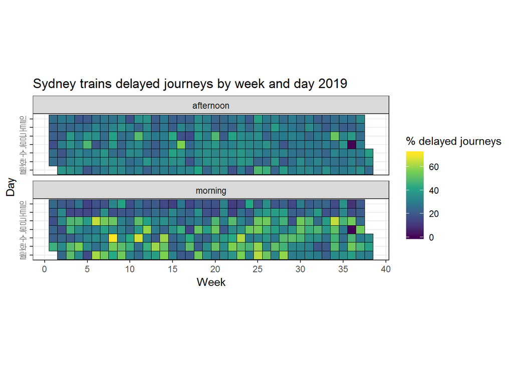

## Delayed journeys by day of week

Next we examine the distribution of delays by day.

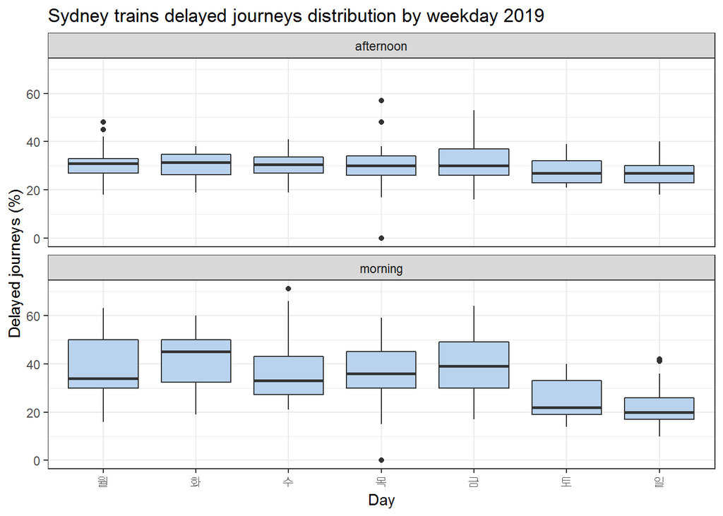

## Delayed journeys by month

The distribution of morning delays by month shows an interesting cyclical pattern, peaking in February and June and dropping off again in January, April and August.

The peaks coincide with months after school holidays - could that be related?

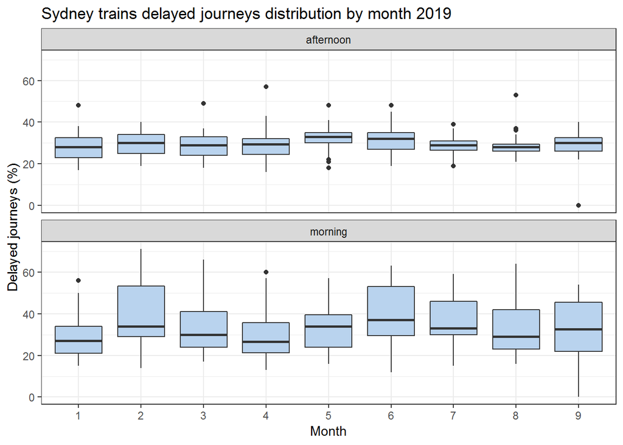

## Longest delayed journeys by service

We count each time a service is named as the most delayed and plot the count for services that occur 5 or more times.

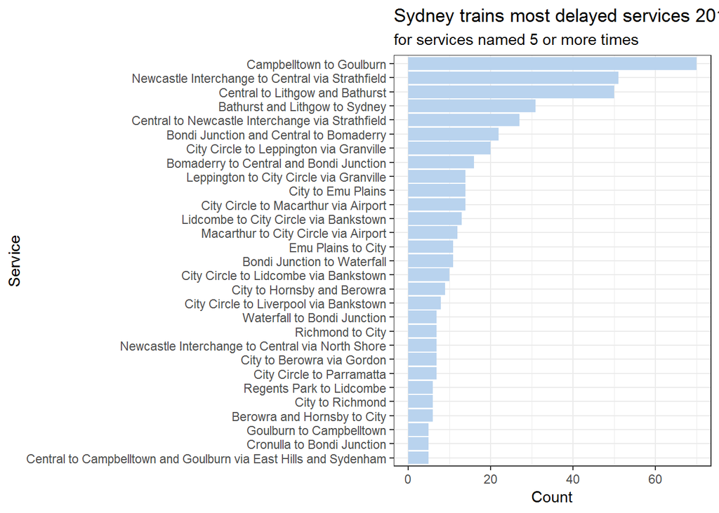

Then we plot the distribution of delay duration for those services, ordered by median delay duration.

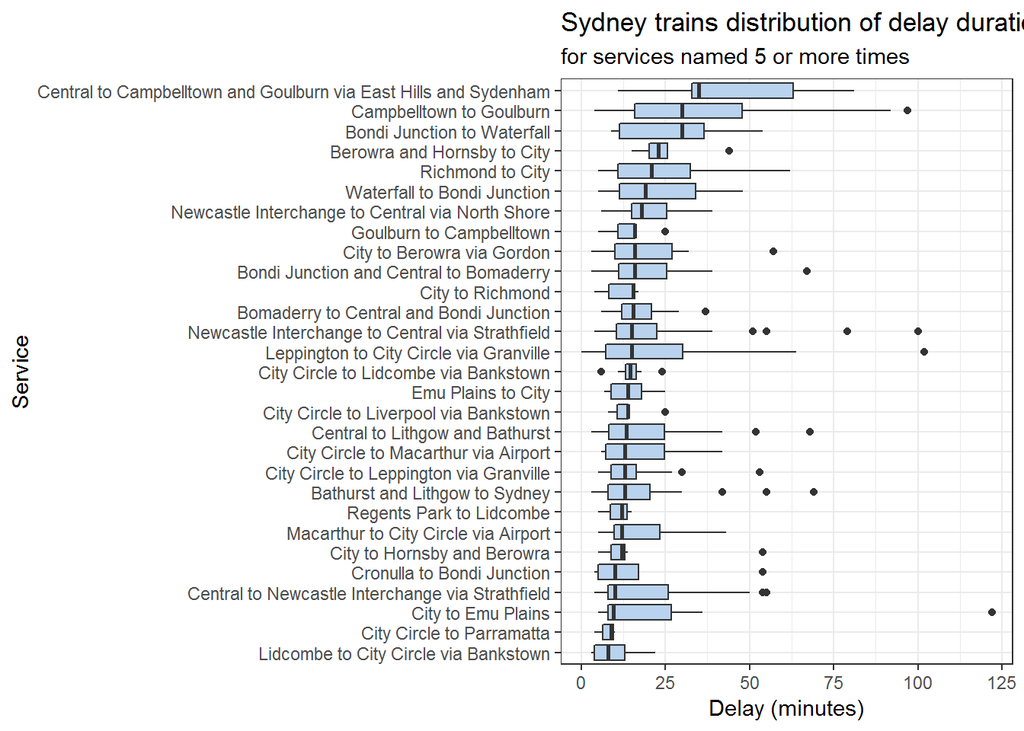

# Summary